# Confidence Intervals

Shikhar Singh

September 14, 2026

# Agenda

### 1. Confidence Intervals

- What Is it?
- Normal Approximation Based CIs
- Randomization Inference Based CIs

### 2. Standardized Effect Sizes

### 3. Making Tables and Coefficient Plots

### 4. Malhotra (2021)

# Confidence Intervals

**Definition:** A confidence interval for $\theta$, loosely speaking, is an estimated *interval* that covers the true value of $\theta$ with at least a given probability. (Aronow and Miller 2019:124)

In other words, a 95% confidence interval, constructed through some procedure (say, based on Normal approximation), contains the true value of the parameter at least 95% of the time. Note that the Normal approximation-based confidence interval refers to an **estimator** that has this property (i.e. it contains the truth with 95% probability). This does not mean that the interval **estimate** we obtain from the data contains the true value of $\theta$ 95% of the times.

Let’s clarify this point. Let me specify a **data generating process** where $Y_i(0) \sim N(\mu = 0, \sigma = 4)$, and $Y_i(1) = Y_i(0) + \tau_i$, where $\tau_i \sim N(\mu = 5, \sigma = 4)$, i.e. the individual-level treatment effect is drawn from a Normal distribution with mean 5 and standard deviation 4. Let’s see what one draw of data from this data generating process looks like:

```r
set.seed(20250911)

library(tidyverse)
library(knitr)

dat1 <- tibble(
  Y0 = rnorm(100, mean = 0, sd = 4),
  Y1 = Y0 + rnorm(100, mean = 5, sd = 4)
)

kable(head(dat1), caption = "Example Dataset", row.names = T)
```

Example Dataset

|  | Y0 | Y1 |
| --- | --- | --- |
| 1 | 3.5360449 | 8.3801635 |
| 2 | 5.6969583 | 11.9073790 |
| 3 | 4.3584237 | 10.9713374 |
| 4 | 0.2947779 | -0.1089062 |
| 5 | -4.4453388 | 4.4435283 |
| 6 | 0.4288416 | -3.4160531 |

The above specification should give us a *true* ATE that is close to 5.

```r
true_ate = mean(dat1$Y1 -dat1$Y0)
true_ate
```

[1] 4.848533

**Question:** Why is the true ATE not exactly 5? What about the data generating process contributes to this?

Now imagine we conduct a large number of experiments. In each experiment (“iteration”), we conduct a new complete random assignment with exactly $m=50$ of $N=100$ subjects assigned to treatment, the remaining $N-m = 50$ to control group. We then apply the switching equation to potential outcomes to obtain observed outcomes, estimate the difference-in-means ($\widehat{\theta}$) *and* a 95% confidence interval for that $\widehat{\theta}$ using the $\widehat{\theta} \pm 1.96 \times SE$ formula. Our expectation is that at least 95% of these confidence intervals contain the true ATE.

Let’s setup this simulation:

```r
library(DeclareDesign)
library(estimatr)

# Step 1: Get a large number of hypothetical assignment vectors

complete_ra_declaration = declare_ra(N = nrow(dat1), m=50)

D_complete_ra <- obtain_permutation_matrix(complete_ra_declaration)

# Step 2: Use one assignment vector (column) at a time and calculate the ATE estimate and CI estimate

ests_complete_ra <- c()

for(i in 1:ncol(D_complete_ra)) {
  dat_temp <- dat1 %>%
    mutate(d_temp = D_complete_ra[, i],
           y_temp = d_temp * Y1 + (1 - d_temp) * Y0)
  estimate = tidy(difference_in_means(y_temp ~ d_temp, data = dat_temp))
  ests_complete_ra = bind_rows(ests_complete_ra, estimate)
}
```

Here is the result of the simulation. I plot the confidence interval from the first 100 iterations (“hypothetical experiments”).

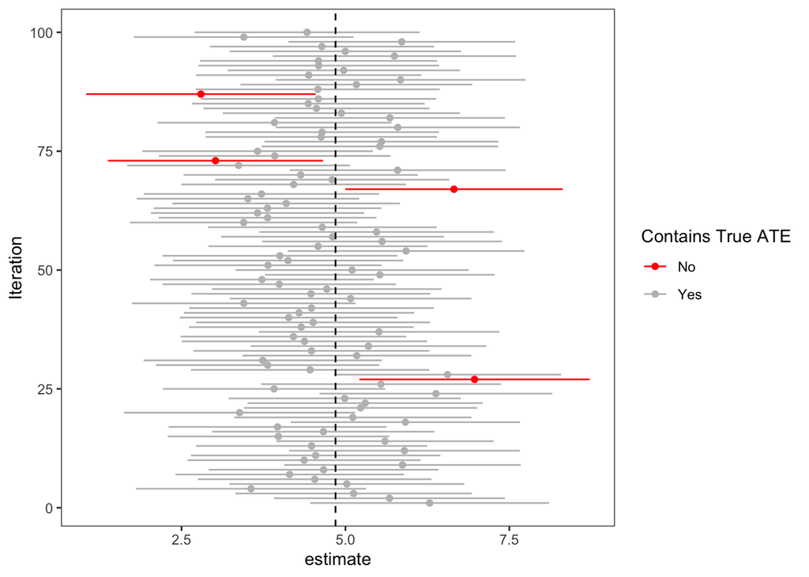

```r
ests_complete_ra <- ests_complete_ra %>%
  mutate(`Contains True ATE` = case_when((conf.low <= true_ate) &
                                           (true_ate <= conf.high) ~ "Yes", TRUE ~ "No"),
         Iteration = row_number())


fig1 <- ggplot(
  data = ests_complete_ra %>% filter(Iteration <= 100),
  aes(x = estimate, y = Iteration, color = `Contains True ATE`)
) +
  geom_point() +
  geom_linerange(aes(xmin = conf.low, xmax = conf.high)) +
  geom_vline(xintercept = true_ate,
             linetype = "dashed",
             color = "black") +
  scale_color_manual(values = c("red", "gray")) +
  theme_bw() +
  theme(panel.grid = element_blank())

fig1
```

**Coverage:** The coverage of a confidence interval is the proportion of times it actually contains the truth. A 95% confidence interval should have a coverage of 0.95, i.e. it should contain the truth 95 out of 100 times, and would not 5% of the time.

In the first hundred iterations (hypothetical experiments), you can see in red how many times the confidence interval does *not* contain the truth. This might be less or more than 5. That is because the first hundred experiments are a small subset of a very large number of possible iterations or hypothetical experiments. Coverage will approximate 95% as the number of iterations tends to $\infty$.

```r
mean(ests_complete_ra$`Contains True ATE` == "Yes")
```

[1] 0.9643

## Types of CIs

We are most familiar with a Wald-type confidence interval:

$\widehat{\theta} \pm 1.96 \times SE$

Gerber and Green (2012) suggest a non-parametric approach to building confidence intervals using randomization inference. We construct these confidence intervals using the following approach:

1. Consider some data set where the outcome is $Y_i$, assignment vector is $d_i$, and the difference-in-means estimate is $\widehat{\theta}$. We want to construct a confidence interval around $\widehat{\theta}$.
2. Lets define two potential outcomes, $Y_{\text{CI}}^0$ (untreated potential outcome) and $Y_{\text{CI}}^1$ treated potential outcome. Given our data, we know one of the two potential outcomes for each subject:

Constructing POs for CI

| Unit | Y | d | Y1 | Y0 |
| --- | --- | --- | --- | --- |
| 1 | 16 | 1 | 16 | ? |
| 2 | 8 | 1 | 8 | ? |
| 3 | 10 | 0 | ? | 10 |
| 4 | 10 | 0 | ? | 10 |

We will impute the missing potential outcome by adding or substracting the difference-in-means estimate ($\widehat{\theta}$) from the known potential outcomes:

Constructing POs for CI

| Unit | Y | d | Y1 | Y0 |
| --- | --- | --- | --- | --- |
| 1 | 16 | 1 | 16 | 16-2 |
| 2 | 8 | 1 | 8 | 8-2 |
| 3 | 10 | 0 | 10+2 | 10 |
| 4 | 10 | 0 | 10+2 | 10 |

3. We will then use the pair of potential outcomes ($Y_{\text{CI}}^1$, $Y_{\text{CI}}^0$) and perform randomization inference: draw a large number of hypothetical assignment vectors, $d_i^*$; for each $d_i^*$ apply the switching equation to get the observed outcome $y_i^*$, estimate the difference-in-means ($\widehat{\theta^*}$), and store it in an output vector.
4. The resulting distribution, sampling distribution of $\widehat{\theta^*}$, will be centered on the observed difference-in-means $\widehat{\theta}$. The 2.5th percentile and 97.5th percentile value will give us the confidence interval.

**Note:**The confidence intervals constructed this way assume constant treatment effect. We are adding or subtracting $\widehat{\theta}$ for every subject.

**Alert:**Gerber and Green (2012) point out that confidence intervals constructed using this approach are *typically* conservative (i.e. they have at least nominal coverage). However, if experimental group sizes are very skewed, this may change. “A rule of thumb is that caution is required if the smaller group is less than half the size of the larger group, and the smaller group’s standard deviation is at least twice a slarge as the larger group’s standard deviation.” (FEDAI:68)

## Randomization Inference

Here is code to construct confidence intervals in the way described above.

```r
# Let's use dat1 from earlier today.

# Step 1: Conduct a random assignment, and obtain a treatment effect estimate

dat1 <- dat1 %>%
  mutate(
    Z = complete_ra(N = 100, m = 50),
    Y = Y1*Z + Y0*(1-Z)
  )

ate_estimate = with(dat1, mean(Y[Z==1]-Y[Z==0]))

kable(ate_estimate, caption = "ATE Estimate", align = "c", col.names = "Estimate")
```

ATE Estimate

| Estimate |
| --- |
| 5.36174 |

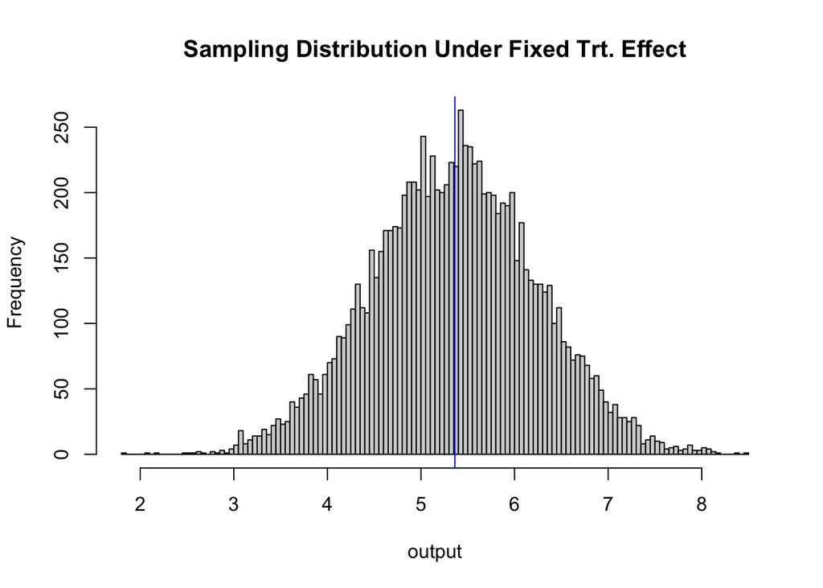

```r
# Step 2: Construct potential outcomes using the ate estimate

dat1 <- dat1 %>%
  mutate(
    Y0_CI = case_when(Z==0 ~ Y, Z==1 ~ Y-ate_estimate),
    Y1_CI = case_when(Z==0 ~ Y+ate_estimate, Z==1 ~ Y)
  )

# Step 3: Obtaining a permutation matrix (all possible assignment vectors)
declaration = declare_ra(N = 100, m = 50)

D <- obtain_permutation_matrix(declaration)

# Step 4: Conduct randomization inference on Y0_CI and Y1_CI

output <- rep(NA, ncol(D))

for(i in 1:ncol(D)){
  Z_temp <- D[,i]
  # Compute ATE
  output[i] <- with(dat1, mean(Y1_CI[Z_temp==1] - Y0_CI[Z_temp==0]))
}


hist(output, breaks = 100, main = "Sampling Distribution Under Fixed Trt. Effect")

abline(v = ate_estimate, col = "blue")
```

```r
ci = quantile(output, probs = c(0.025, 0.975))

kable(ci, caption = "Confidence Intervals", align = "c", col.names = "Estimate")
```

Confidence Intervals

|  | Estimate |
| --- | --- |
| 2.5% | 3.635257 |
| 97.5% | 7.075393 |

# Standardized Effect Size

Confidence intervals, hypothesis tests and p-values are all tools that help us interpret the magnitude and importance of a treatment effect. Another such tool is *standardization*.

**Problem:** Say there are two experiments, with exactly the same intervention, but one measures outcomes on a continuous scale between 0 and 10, the other as a binary choice, 0 or 1. The experiments produce two ATE estimates, $\widehat{\theta_1}$ and $\widehat{\theta_2}$, but how do they compare? The estimates are on different scales, and it is not immediately clear which is larger, or how similar they are.

The intuition behind standardization is that all treatment effects can be expressed as a z-score, essentially a distance in standard deviation units from the control group which is mean-centered at 0, with a standard deviation of 1.

> To standardize, take the outcome $y_i$, subtract the control group mean ($\overline{y_{Z=O}}$) from each observation, and divide by the control group standard deviation ($\sigma_{Z=O}$). $y_{i}^* = \frac{y_i - \overline{y_{Z=O}}}{\sigma_{Z=O}}$. Now use $y_{i}^*$ while estimating the difference-in-means.

# Making Tables and Plots

We will use `tidyverse`, `estimatr` and `kableExtra` to make tables and plots in R. Time permitting, I will go over some code but here it is for your reference:

Estimating treatment effects using `estimatr`, making tables using `kableExtra` or `texreg`.

The following is a helpful resource for `kableExtra`: https://cran.r-project.org/web/packages/kableExtra/vignettes/awesome_table_in_html.html

```r
# Estimating treatment effects
library(kableExtra)
library(estimatr)
library(texreg)

fit1 <- lm_robust(Y ~ Z, data = dat1)

kbl(tidy(fit1) %>% select(-df,-outcome),
    format = "html",
    digits = 2) %>%
  kable_classic()
```

| term | estimate | std.error | statistic | p.value | conf.low | conf.high |
| --- | --- | --- | --- | --- | --- | --- |
| (Intercept) | -1.19 | 0.55 | -2.19 | 0.03 | -2.28 | -0.11 |
| Z | 5.36 | 0.88 | 6.11 | 0.00 | 3.62 | 7.10 |

```r
htmlreg(list(fit1),
        digits = 3,
        include.ci=FALSE)
```

Statistical models

|  | Model 1 |
| --- | --- |
| (Intercept) | -1.194* |
|  | (0.546) |
| Z | 5.362*** |
|  | (0.878) |
| R<sup>2</sup> | 0.276 |
| Adj. R<sup>2</sup> | 0.268 |
| Num. obs. | 100 |
| RMSE | 4.390 |

***p < 0.001; **p < 0.01; *p < 0.05

For making plots, we rely on ggplot.

**Step 1:** Estimating group means using `group_by`

```r
dat_group_means <-
  dat1 %>%
  group_by(Z) %>%
  summarize(tidy(lm_robust(Y ~ 1, data = cur_data())))


kable(dat_group_means,
      digits = 3,
      caption = "Group Means",
      caption.above = TRUE) %>%
    kable_classic()
```

Group Means

| Z | term | estimate | std.error | statistic | p.value | conf.low | conf.high | df | outcome |
| --- | --- | --- | --- | --- | --- | --- | --- | --- | --- |
| 0 | (Intercept) | -1.194 | 0.546 | -2.188 | 0.033 | -2.291 | -0.097 | 49 | Y |
| 1 | (Intercept) | 4.168 | 0.688 | 6.060 | 0.000 | 2.786 | 5.550 | 49 | Y |

**Step 2:** Using `ggplot2` to make a figure. We use the `ggpubr` package’s `geom_bracket` function to make the difference-in-means bracket in the figure.

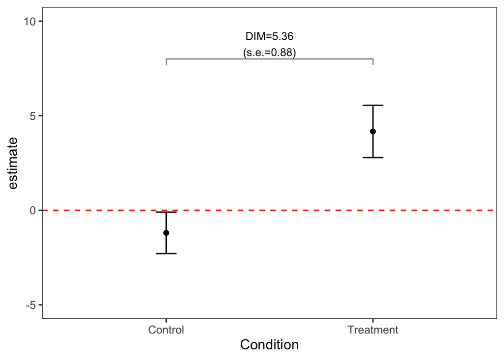

```r
# Convert Z from a 0/1 to Control/Treatment Variable

dat_group_means <- dat_group_means %>%
  mutate(Condition = case_when(Z == 0 ~ "Control",
                               Z == 1 ~ "Treatment"))

# Create a label for difference-in-means estimate

fit2 <- difference_in_means(Y ~ Z, data = dat1)

label_dim <- tibble(
  xmin = 1,
  xmax = 2,
  y_position = 8,
  label = paste0(
    "DIM=",
    round(fit2$coefficients, 2),
    "\n(s.e.=",
    round(fit2$std.error, 2),
    ")"
  )
)


# Make the plot
library(ggpubr) # use for DIM bracket

ggplot(dat_group_means, aes(y = estimate, x = Condition)) +
  geom_point() +
  geom_errorbar(aes(ymin = conf.low, ymax = conf.high), width = 0.1) +
  geom_hline(yintercept = 0,
             linetype = "dashed",
             color = "red") +
  geom_bracket(data = label_dim,
               aes(xmin = xmin, xmax = xmax, y.position = y_position, label = label))+
  scale_y_continuous(limits = c(-5,10)) +
  theme_bw(base_size = 14) +
  theme(panel.grid = element_blank())
```